# Icm.Microarray.RNASeq

Enrique ESCOBAR

20 Feb 2017

# R Project Setup

A file Script.R that sets paths.

# Abstract

The ability to easily and efficiently analyse RNA-sequencing data is a key strength of the **Bioconductor** project. Starting with counts summarised at the gene-level, a typical analysis involves pre-processing, exploratory data analysis, differential expression testing and pathway analysis with the results obtained informing future experiments and validation studies. In this workflow article, we analyse RNA-sequencing data from the mouse mammary gland, demonstrating use of the popular **edgeR** package to import, organise, filter and normalise the data, followed by the **limma** package with its *voom* method, linear modelling and **empirical Bayes** moderation to assess differential expression and perform gene set testing. This pipeline is further enhanced by the **Glimma** package which enables interactive exploration of the results so that individual samples and genes can be examined by the user. The complete analysis offered by these three packages highlights the ease with which researchers can turn the raw counts from an RNA-sequencing experiment into biological insights using Bioconductor.

# Introduction

RNA-sequencing (RNA-seq) has become the primary technology used for gene expression profiling, with the genomewide detection of differentially expressed genes between two or more conditions of interest one of the most commonly asked questions by researchers. The **edgeR** and **limma** packages available from the **Bioconductor** project offer a well-developed suite of statistical methods for dealing with this question for RNA-seq data. In this article, we describe an **edgeR** - **limma** workflow for analysing RNA-seq data that takes gene-level counts as its input, and moves through pre-processing and exploratory data analysis before obtaining lists of differentially expressed (DE) genes and gene signatures. This analysis is enhanced through the use of interactive graphics from the **Glimma** package , that allows for a more detailed exploration of the data at both the sample and gene-level than is possible using static R plots. The experiment analysed in this workflow is from Sheridan *et al*. (2015) and consists of three cell populations (basal, luminal progenitor (LP) and mature luminal (ML)) sorted from the mammary glands of female virgin mice, each profiled in triplicate. RNA samples were sequenced across three batches on an Illumina HiSeq 2000 to obtain 100 base-pair single-end reads. The analysis outlined in this article assumes that reads obtained from an RNA-seq experiment have been aligned to an appropriate reference genome and summarised into counts associated with gene-specific regions. In this instance, reads were aligned to the mouse reference genome (*mm10*) using the R based pipeline available in the **Rsubread** package (specifically the align function6 followed by featureCounts for gene-level summarisation based on the in-built *mm10* RefSeq-based annotation). Count data for these samples can be downloaded from the Gene Expression Omnibus (GEO) using GEO Series accession number GSE63310. Further information on experimental design and sample preparation is also available from GEO under this accession number

# Data packaging

## Reading

To get started with this analysis, download the file **GSE63310_RAW.tar** available online from http://www.ncbi.nlm.nih.gov/geo/download/?acc=GSE63310&format=file, and extract the relevant files from this archive. Each of these text files contains the raw gene-level counts for a given sample. Note that our analysis only includes the basal, LP and ML samples from this experiment (see associated file names below).

```r
source(paste0("Lib/", projectName, ".Util.R"));
fileList <- c("Data/GSM1545535_10_6_5_11.txt",
           "Data/GSM1545536_9_6_5_11.txt",
           "Data/GSM1545538_purep53.txt",
           "Data/GSM1545539_JMS8-2.txt",
           "Data/GSM1545540_JMS8-3.txt",
           "Data/GSM1545541_JMS8-4.txt",
           "Data/GSM1545542_JMS8-5.txt",
           "Data/GSM1545544_JMS9-P7c.txt",
           "Data/GSM1545545_JMS9-P8c.txt");
```

Whilst each of the nine text files can be read into R separately and combined into a matrix of counts, **edgeR** offers a convenient way to do this in one step using the readDGE function. The resulting DGEList-object contains a matrix of counts with 27,179 rows associated with unique Entrez gene identifiers (IDs) and nine columns associated with the individual samples in the experiment.

# GeneNames *col1* & GeneCount *col3*

```r
df <- TxtFileToDataFrame(fileList[1]);
head(df);
```

```
##    EntrezID GeneLength Count
## 1    497097       3634     1
## 2 100503874       3259     0
## 3 100038431       1634     0
## 4     19888       9747     0
## 5     20671       3130     1
## 6     27395       4203   431
```

```r
geneColumns <- which(colnames(df) == "EntrezID" | colnames(df) == "Count");
geneColumns;
```

```
## [1] 1 3
```

```r
geneKeyType <- toupper(colnames(df)[1]);
geneKeyType;
```

```
## [1] "ENTREZID"
```

```r
rm(df);
source(paste0("Lib/", "edgeR.Util.R"));
x <- GeneNameAndCountDGEList(fileList, geneColumns);
dim(x);
```

```
## [1] 27179     9
```

If the counts from all samples were stored in a single file, the data can be read into R and then converted into a DGEList-object using the DGEList function.

## Organising sample information

For downstream analysis, sample-level information related to the experimental design needs to be associated with the columns of the counts matrix. This should include experimental variables, both biological and technical, that could have an effect on expression levels. Examples include cell type (basal, LP and ML in this experiment), genotype (wild-type, knock-out), phenotype (disease status, sex, age), sample treatment (drug, control) and batch information (date experiment was performed if samples were collected and analysed at distinct time points) to name just a few. Our DGEList-object contains a samples data frame that stores both cell type (or group) and batch (sequencing lane) information, each of which consists of three distinct levels. Note that within x$samples, library sizes are automatically calculated for each sample and normalisation factors are set to 1. For simplicity, we remove the GEO sample IDs (GSM*) from the column names of our DGEList-object x.

```r
### shrink colnames remove from start to first underscore
colnames(x);
```

```
## [1] "Data/GSM1545535_10_6_5_11" "Data/GSM1545536_9_6_5_11"
## [3] "Data/GSM1545538_purep53"   "Data/GSM1545539_JMS8-2"
## [5] "Data/GSM1545540_JMS8-3"    "Data/GSM1545541_JMS8-4"
## [7] "Data/GSM1545542_JMS8-5"    "Data/GSM1545544_JMS9-P7c"
## [9] "Data/GSM1545545_JMS9-P8c"
```

```r
samplenames <- substring(colnames(x), 17, nchar(colnames(x))) ; #12->17
samplenames;
```

```
## [1] "10_6_5_11" "9_6_5_11"  "purep53"   "JMS8-2"    "JMS8-3"    "JMS8-4"
## [7] "JMS8-5"    "JMS9-P7c"  "JMS9-P8c"
```

```r
colnames(x) <- samplenames;
# col group & norm.factors preset to 1
x$samples;
```

```
##                                   files group lib.size norm.factors
## 10_6_5_11 Data/GSM1545535_10_6_5_11.txt     1 32863052            1
## 9_6_5_11   Data/GSM1545536_9_6_5_11.txt     1 35335491            1
## purep53     Data/GSM1545538_purep53.txt     1 57160817            1
## JMS8-2       Data/GSM1545539_JMS8-2.txt     1 51368625            1
## JMS8-3       Data/GSM1545540_JMS8-3.txt     1 75795034            1
## JMS8-4       Data/GSM1545541_JMS8-4.txt     1 60517657            1
## JMS8-5       Data/GSM1545542_JMS8-5.txt     1 55086324            1
## JMS9-P7c   Data/GSM1545544_JMS9-P7c.txt     1 21311068            1
## JMS9-P8c   Data/GSM1545545_JMS9-P8c.txt     1 19958838            1
```

```r
### group factor foreach-9
group <- as.factor(c("LP", "ML", "Basal", "Basal", "ML", "LP", "Basal", "ML", "LP")) ;
x$samples$group <- group;
x$samples;
```

```
##                                   files group lib.size norm.factors
## 10_6_5_11 Data/GSM1545535_10_6_5_11.txt    LP 32863052            1
## 9_6_5_11   Data/GSM1545536_9_6_5_11.txt    ML 35335491            1
## purep53     Data/GSM1545538_purep53.txt Basal 57160817            1
## JMS8-2       Data/GSM1545539_JMS8-2.txt Basal 51368625            1
## JMS8-3       Data/GSM1545540_JMS8-3.txt    ML 75795034            1
## JMS8-4       Data/GSM1545541_JMS8-4.txt    LP 60517657            1
## JMS8-5       Data/GSM1545542_JMS8-5.txt Basal 55086324            1
## JMS9-P7c   Data/GSM1545544_JMS9-P7c.txt    ML 21311068            1
## JMS9-P8c   Data/GSM1545545_JMS9-P8c.txt    LP 19958838            1
```

```r
#rm(group);
### lane factor foreach-9
lane <- as.factor(rep(c("L004", "L006", "L008"), c(3, 4, 2))) ;
x$samples$lane <- lane;
x$samples;
```

```
##                                   files group lib.size norm.factors lane
## 10_6_5_11 Data/GSM1545535_10_6_5_11.txt    LP 32863052            1 L004
## 9_6_5_11   Data/GSM1545536_9_6_5_11.txt    ML 35335491            1 L004
## purep53     Data/GSM1545538_purep53.txt Basal 57160817            1 L004
## JMS8-2       Data/GSM1545539_JMS8-2.txt Basal 51368625            1 L006
## JMS8-3       Data/GSM1545540_JMS8-3.txt    ML 75795034            1 L006
## JMS8-4       Data/GSM1545541_JMS8-4.txt    LP 60517657            1 L006
## JMS8-5       Data/GSM1545542_JMS8-5.txt Basal 55086324            1 L006
## JMS9-P7c   Data/GSM1545544_JMS9-P7c.txt    ML 21311068            1 L008
## JMS9-P8c   Data/GSM1545545_JMS9-P8c.txt    LP 19958838            1 L008
```

## Gene annotations

A second data frame named genes in the DGEList-object is used to store gene-level information associated with rows of the counts matrix. This information can be retrieved using organism specific packages such as **Mus.musculus** for mouse (or **Homo.sapiens** for human) or the **biomaRt** package which interfaces the Ensembl genome databases in order to perform gene annotation. The type of information that can be retrieved includes gene symbols, gene names, chromosome names and locations, Entrez gene IDs, Refseq gene IDs and Ensembl gene IDs to name just a few. **biomaRt** primarily works off Ensembl gene IDs, whereas **Mus.musculus** packages information from various sources and allows users to choose between many different gene IDs as the key. The Entrez gene IDs available in our dataset were annotated using the **Mus.musculus** package to retrieve associated gene symbols and chromosome information

As with any gene ID, Entrez gene IDs may not map one-to-one to the gene information of interest. It is important to check for duplicated gene IDs and to understand the source of duplication before resolving them. Our gene annotation contains 28 genes that map to multiple chromosomes (e.g. gene Gm1987 is associated with “chr4” and “chr4_JH584294_random” and microRNA Mir5098 is associated with “chr2”, “chr5”, “chr8”, “chr11” and “chr17”). To resolve duplicate gene IDs one could combine all chromosome information from the multi-mapped genes, such that gene Gm1987 would be is assigned to “chr4 and chr4_JH584294_random”, or select one of the chromosomes to represent the gene with duplicate annotation. For simplicity we do the latter, keeping only the first occurrence of each gene ID.

In this example, the gene order is the same in both the annotation and the data object. If this is not the case due to missing and/or rearranged gene IDs, the match function can be used to order genes correctly. The data frame of gene annotations is then added to the data object and neatly packaged in a DGEList-object containing raw count data with associated sample information and gene annotations.

```r
# loads library
# AnnotationDbi, stats4, BiocGenerics, parallel, Biobase, IRanges, S4Vectors
# OrganismDbi, GenomicFeatures, GenomeInfoDb, GenomicRanges, GO.db, org.Mm.eg.db,
# TxDb.Mmusculus.UCSC.mm10.knownGene
head(rownames(x), 10);
```

```
##  [1] "497097"    "100503874" "100038431" "19888"     "20671"
##  [6] "27395"     "18777"     "100503730" "21399"     "58175"
```

```r
geneIdKeys <- rownames(x) ;
### foearch rowname select cols in ENTREZID
geneColumns <- c("SYMBOL", "TXCHROM");
#genes <- AnnotationDbi::select(Mus.musculus, keys = geneIdKeys, columns = geneColumns, keytype = geneKeyType);
# select() returned 1:many mapping between keys and columns
genes <- EntrezIdSymbolChromosome(geneList = geneIdKeys, geneColumns = geneColumns, geneKeyType = geneKeyType);
dim(genes);
```

```
## [1] 27220     3
```

```r
colnames(genes);
```

```
## [1] "ENTREZID" "SYMBOL"   "TXCHROM"
```

```r
head(genes);
```

```
##    ENTREZID  SYMBOL TXCHROM
## 1    497097    Xkr4    chr1
## 2 100503874 Gm19938    <NA>
## 3 100038431 Gm10568    <NA>
## 4     19888     Rp1    chr1
## 5     20671   Sox17    chr1
## 6     27395  Mrpl15    chr1
```

```r
### rm duplicates
genes <- genes[!duplicated(genes$ENTREZID),];
dim(genes);
```

```
## [1] 27179     3
```

```r
colnames(genes);
```

```
## [1] "ENTREZID" "SYMBOL"   "TXCHROM"
```

```r
head(genes);
```

```
##    ENTREZID  SYMBOL TXCHROM
## 1    497097    Xkr4    chr1
## 2 100503874 Gm19938    <NA>
## 3 100038431 Gm10568    <NA>
## 4     19888     Rp1    chr1
## 5     20671   Sox17    chr1
## 6     27395  Mrpl15    chr1
```

```r
### match genes
x$genes <- genes;
x;
```

```
## An object of class "DGEList"
## $samples
##                                   files group lib.size norm.factors lane
## 10_6_5_11 Data/GSM1545535_10_6_5_11.txt    LP 32863052            1 L004
## 9_6_5_11   Data/GSM1545536_9_6_5_11.txt    ML 35335491            1 L004
## purep53     Data/GSM1545538_purep53.txt Basal 57160817            1 L004
## JMS8-2       Data/GSM1545539_JMS8-2.txt Basal 51368625            1 L006
## JMS8-3       Data/GSM1545540_JMS8-3.txt    ML 75795034            1 L006
## JMS8-4       Data/GSM1545541_JMS8-4.txt    LP 60517657            1 L006
## JMS8-5       Data/GSM1545542_JMS8-5.txt Basal 55086324            1 L006
## JMS9-P7c   Data/GSM1545544_JMS9-P7c.txt    ML 21311068            1 L008
## JMS9-P8c   Data/GSM1545545_JMS9-P8c.txt    LP 19958838            1 L008
##
## $counts
##            Samples
## Tags        10_6_5_11 9_6_5_11 purep53 JMS8-2 JMS8-3 JMS8-4 JMS8-5
##   497097            1        2     342    526      3      3    535
##   100503874         0        0       5      6      0      0      5
##   100038431         0        0       0      0      0      0      1
##   19888             0        1       0      0     17      2      0
##   20671             1        1      76     40     33     14     98
##            Samples
## Tags        JMS9-P7c JMS9-P8c
##   497097           2        0
##   100503874        0        0
##   100038431        0        0
##   19888            1        0
##   20671           18        8
## 27174 more rows ...
##
## $genes
##    ENTREZID  SYMBOL TXCHROM
## 1    497097    Xkr4    chr1
## 2 100503874 Gm19938    <NA>
## 3 100038431 Gm10568    <NA>
## 4     19888     Rp1    chr1
## 5     20671   Sox17    chr1
## 27174 more rows ...
```

# Data pre-processing

## Transformations from the raw-scale

For differential expression and related analyses, gene expression is rarely considered at the level of raw counts since libraries sequenced at a greater depth will result in higher counts. Rather, it is common practice to transform raw counts onto a scale that accounts for such library size differences. Popular transformations include counts per million (CPM), log2 -counts per million (log-CPM), reads per kilobase of transcript per million (RPKM), and fragments per kilobase of transcript per million (FPKM). In our analyses, CPM and log-CPM transformations are used regularly although they do not account for feature length differences which RPKM and FPKM values do. Whilst RPKM and FPKM values can just as well be used, CPM and log-CPM values can be calculated using a counts matrix alone and will suffice for the type of comparisons we are interested in. Assuming that there are no differences in isoform usage between conditions, differential expression analyses look at gene expression changes between conditions rather than comparing expression across multiple genes or drawing conclusions on absolute levels of expression. In other words, gene lengths remain constant for comparisons of interest and any observed differences are a result of changes in condition rather than changes in gene length. Here raw counts are converted to CPM and log-CPM values using the cpm function in **edgeR**, where logtransformations use a prior count of 0.25 to avoid taking the log of zero. RPKM values are just as easily calculated as CPM values using the rpkm function in **edgeR** if gene lengths are available.

```r
#simpleCountsPerMillion <- edgeR::cpm(x) ;
simpleCountsPerMillion <- CountsPerMillion(x);
#logCountsPerMillion <- edgeR::cpm(x, log = TRUE);
logCountsPerMillion <- CountsPerMillion(x, TRUE);
```

## Removing genes that are lowly expressed

All datasets will include a mix of genes that are expressed and those that are not expressed. Whilst it is of interest to examine genes that are expressed in one condition but not in another, some genes are unexpressed throughout all samples. In fact, 19% of genes in this dataset have zero counts across all nine samples.

```r
## Removing genes that are lowly expressed
table(rowSums(x$counts == 0) == 9);
```

```
##
## FALSE  TRUE
## 22026  5153
```

Genes that are not expressed at a biologically meaningful level in any condition should be discarded to reduce the subset of genes to those that are of interest, and to reduce the number of tests carried out downstream when looking at differential expression. Upon examination of log-CPM values, it can be seen that a large proportion of genes within each sample is unexpressed or lowly-expressed (Figure 1A). Genes are deemed to be expressed if their CPM value is above a threshold (we use a nominal CPM value of 1), and unexpressed otherwise. A CPM value of 1 is equivalent to a log-CPM value of 0. Genes must be expressed in at least one group (or in at least three samples across the entire experiment, where three was chosen as this is the smallest group size) to be kept for downstream analysis. Although any sensible value can be used as the expression cutoff, typically a CPM value of 1 is used in our analyses as it separates expressed genes from unexpressed genes well for most datasets. Here, a CPM value of 1 means that a gene is “expressed” if it has at least 20 counts in the sample with the lowest sequencing depth (JMS9-P8c, library size ≈20 million) or at least 76 counts in the sample with the greatest sequencing depth (JMS8-3, library size ≈76 million). If sequence reads are summarised by exons rather than genes and/or experiments have low sequencing depth, a lower CPM cutoff may be considered.

Using this criterion, the number of genes is reduced to approximately half the number that we started with (14,165 genes, Figure 1B). Note that subsetting the entire DGEList-object removes both the counts as well as the associated gene information. Code to produce Figure 1 is given below.

```r
keep.exprs <- rowSums(simpleCountsPerMillion > 1) >= 3;
x <- x[keep.exprs, , keep.lib.sizes = FALSE];
dim(x);
```

```
## [1] 14165     9
```

```r
#library(RColorBrewer);
source(paste0("Lib/", "RColorBrewer.Util.R"));
```

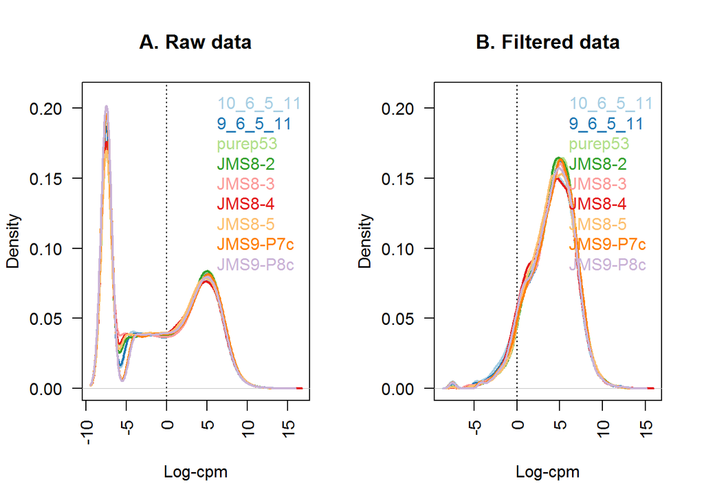

```r
sampleCount <- ncol(x);
#pairedColors <- RColorBrewer::brewer.pal(sampleCount, "Paired");
pairedColors <- ColorPalette(sampleCount, "Paired");
par(mfrow = c(1, 2));
plot(density(logCountsPerMillion[, 1]), col = pairedColors[1], lwd = 2, ylim = c(0, 0.21), las = 2, main = "", xlab = "");
title(main = "A. Raw data", xlab = "Log-cpm");
abline(v = 0, lty = 3);
for (i in 2:sampleCount){
  den <- density(logCountsPerMillion[, i]);
  lines(den$x, den$y, col = pairedColors[i], lwd = 2);
}
legend("topright", samplenames, text.col = pairedColors, bty = "n");

#logCountsPerMillion <- edgeR::cpm(x, log = TRUE);
logCountsPerMillion <- CountsPerMillion(x, TRUE);
plot(density(logCountsPerMillion[, 1]), col = pairedColors[1], lwd = 2, ylim = c(0, 0.21), las = 2, main = "", xlab = "");
title(main = "B. Filtered data", xlab = "Log-cpm");
abline(v = 0, lty = 3);
for (i in 2:sampleCount){
  den <- density(logCountsPerMillion[, i]);
  lines(den$x, den$y, col = pairedColors[i], lwd = 2);
}
legend("topright", samplenames, text.col = pairedColors, bty = "n");
```

**Figure 1.** The density of log-CPM values for raw pre-filtered data (A) and post-filtered data (B) are shown for each sample. Dotted vertical lines mark the log-CPM of zero threshold (equivalent to a CPM value of 1) used in the filtering step.

## Normalizing gene expression distributions

During the sample preparation or sequencing process, external factors that are not of biological interest can affect the expression of individual samples. For example, samples processed in the first batch of an experiment can have higher expression overall when compared to samples processed in a second batch. It is assumed that all samples should have a similar range and distribution of expression values. Normalisation is required to ensure that the expression distributions of each sample are similar across the entire experiment. Any plot showing the per sample expression distributions, such as a density or boxplot, is useful in determining whether any samples are dissimilar to others. Distributions of log-CPM values are similar throughout all samples within this dataset (Figure 1B). Nonetheless, normalisation by the method of trimmed mean of M-values (TMM) is performed using the calcNormFactors function in **edgeR**. The normalisation factors calculated here are used as a scaling factor for the library sizes. When working with DGEList-objects, these normalisation factors are automatically stored in x$samples$norm.factors. For this dataset the effect of TMM-normalisation is mild, as evident in the magnitude of the scaling factors, which are all relatively close to 1.

To give a better visual representation of the effects of normalisation, the data was duplicated then adjusted so that the counts of the first sample are reduced to 5% of their original values, and in the second sample they are inflated to be 5-times larger.

```r
#x <- edgeR::calcNormFactors(x, method = "TMM");
x <- CalculateNormalizationFactors(x, "TMM");
x$samples$norm.factors;
```

```
## [1] 0.8957309 1.0349196 1.0439552 1.0405040 1.0323599 0.9223424 0.9836603
## [8] 1.0827381 0.9792607
```

```r
x2 <- x
x2$samples$norm.factors <- 1;
x2$counts[, 1] <- ceiling(x2$counts[, 1]*0.05);
x2$counts[, 2] <- x2$counts[, 2]*5;
par(mfrow = c(1, 2));
#logCountsPerMillion <- edgeR::cpm(x2, log=TRUE);
logCountsPerMillion <- CountsPerMillion(x2, TRUE);
boxplot(logCountsPerMillion, las = 2, col = pairedColors, main ="");
title(main = "A. Example: Unnormalised data", ylab = "Log-cpm");

#x2 <- edgeR::calcNormFactors(x2);
x2 <- CalculateNormalizationFactors(x2);
x2$samples$norm.factors;
```

```
## [1] 0.05472223 6.13059440 1.22927355 1.17051887 1.21487709 1.05622968
## [7] 1.14587663 1.26129350 1.11702264
```

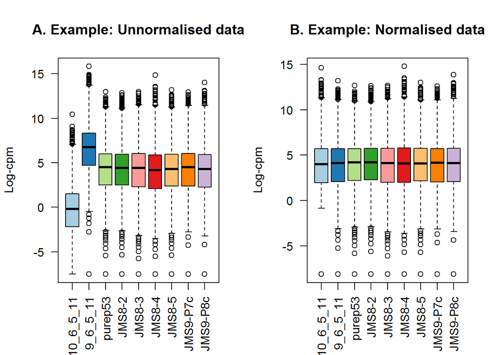

```r
#logCountsPerMillion <- edgeR::cpm(x2, log=TRUE);
logCountsPerMillion <- CountsPerMillion(x2, TRUE);
boxplot(logCountsPerMillion, las = 2, col = pairedColors, main = "");
title(main = "B. Example: Normalised data", ylab = "Log-cpm");
```

**Figure 2.** It shows the expression distribution of samples for unnormalised and normalised data, where distributions are noticeably different pre-normalisation and are similar post-normalisation. Here the first sample has a small TMM scaling factor of 0.05, whereas the second sample has a large scaling factor of 6.13 – neither values are close to 1.

## Unsupervised clustering of samples

In our opinion, one of the most important exploratory plots to examine for gene expression analyses is the multidimensional scaling (MDS) plot, or similar. The plot shows similarities and dissimilarities between samples in an unsupervised manner so that one can have an idea of the extent to which differential expression can be detected before carrying out formal tests. Ideally, samples would cluster well within the primary condition of interest, and any sample straying far from its group could be identified and followed up for sources of error or extra variation. If present, technical replicates should lie very close to one another. Such a plot can be made in **limma** using the plotMDS function. The first dimension represents the leadingfold-change that best separates samples and explains the largest proportion of variation in the data, with subsequent dimensions having a smaller effect and being orthogonal to the ones before it. When experimental design involves multiple factors, it is recommended that each factor is examined over several dimensions. If samples cluster by a given factor in any of these dimensions, it suggests that the factor contributes to expression differences and is worth including in the linear modelling. On the other hand, factors that show little or no effect may be left out of downstream analysis. In this dataset, samples can be seen to cluster well within experimental groups over dimension 1 and 2, and then separate by sequencing lane (sample batch) over dimension 3 (Figure 3). Keeping in mind that the first dimension explains the largest proportion of variation in the data, notice that the range of values over the dimensions become smaller as we move to higher dimensions. Whilst all samples cluster by groups, the largest transcriptional difference is observed between basal and LP, and basal and ML over dimension 1. For this reason, it is expected that pairwise comparisons between cell populations will result in a greater number of DE genes for comparisons involving basal samples, and relatively small numbers of DE genes when comparing ML to LP. Datasets where samples do not cluster by experimental group may show little or no evidence of differential expression in the downstream analysis. To create the MDS plots, we assign different colours to the factors of interest. Dimensions 1 and 2 are examined using the colour grouping defined by cell types.

Dimensions 3 and 4 are examined using the colour grouping defined by sequencing lanes (batch).

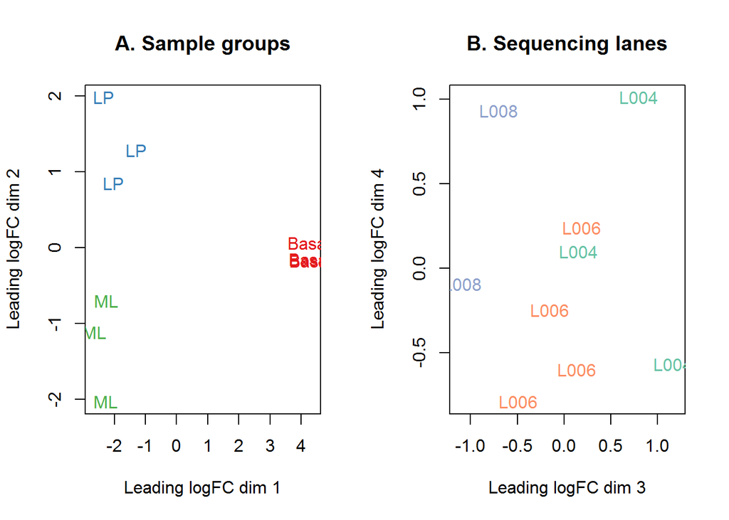

```r
#logCountsPerMillion <- edgeR::cpm(x, log=TRUE);
logCountsPerMillion <- CountsPerMillion(x, TRUE);
par(mfrow = c(1,2));
col.group <- group;
#levels(col.group) <- RColorBrewer::brewer.pal(nlevels(col.group), "Set1");
levels(col.group) <- ColorPalette(nlevels(col.group), "Set1");

col.group <- as.character(col.group);
col.lane <- lane;
#levels(col.lane) <- RColorBrewer::brewer.pal(nlevels(col.lane), "Set2");
levels(col.lane) <- ColorPalette(nlevels(col.lane), "Set2");

col.lane <- as.character(col.lane);
#library(limma)
source(paste0("Lib/", "limma.Util.R"));
#limma::plotMDS(logCountsPerMillion, labels = group, col = col.group);
PlotMultiDimensionalScaling(logCountsPerMillion, group, col.group);
title(main="A. Sample groups");

#limma::plotMDS(logCountsPerMillion, labels = lane, col = col.lane, dim = c(3,4));
PlotMultiDimensionalScalingFixed(logCountsPerMillion, lane, col.lane, c(3,4));
title(main="B. Sequencing lanes");
```

```r
## http://bioinf.wehi.edu.au/folders/limmaWorkflow/glimma-plots/MDS-Plot.html
#source("https://bioconductor.org/biocLite.R");
#biocLite("Glimma");
library(Glimma);
Glimma::glMDSPlot(logCountsPerMillion, labels = paste(group, lane, sep = "_"), groups = x$samples[,c(2,5)], launch = FALSE);
```

**Figure 3.** MDS plots of log-CPM values over dimensions 1 and 2 with samples coloured and labeled by sample groups (A) and over dimensions 3 and 4 with samples coloured and labeled by sequencing lane (B). Distances on the plot correspond to the leading fold-change, which is the average (root-mean-square) log2 -fold-change for the 500 genes most divergent between each pair of samples by default.

Alternatively, the **Glimma** package offers the convenience of an interactive MDS plot where multiple dimensions can be explored. The glMDSPlot function generates an html page (that is opened in a browser if launch=TRUE) with an MDS plot in the left panel and a barplot showing the proportion of variation explained by each dimension in the right panel. Clicking on the bars of the bar plot changes the pair of dimensions plotted in the MDS plot, and hovering over the individual points reveals the sample label. The colour scheme can be changed as well to highlight cell population or sequencing lane (batch). An interactive MDS plot of this dataset can be found at http://bioinf.wehi.edu.au/folders/limmaWorkflow/glimma-plots/MDS-Plot.html

# Differential Expression *DE* analysis

## Creating a design matrix and contrasts

In this study, it is of interest to see which genes are expressed at different levels between the three cell populations profiled. In our analysis, linear models are fitted to the data with the assumption that the underlying data is normally distributed. To get started, a design matrix is set up with both the cell population and sequencing lane (batch) information.

For a given experiment, there are usually several equivalent ways to set up an appropriate design matrix. For example, ~0+group+lane removes the intercept from the first factor, group, but an intercept remains in the second factor lane. Alternatively, ~group+lane could be used to keep the intercepts in both group and lane. Understanding how to interpret the coefficients estimated in a given model is key here. We choose the first model for our analysis, as setting up model contrasts is more straight forward in the absence of an intercept for group. Contrasts for pairwise comparisons between cell populations are set up in **limma** using the makeContrasts function.

```r
## Creating a design matrix and contrasts
design <- model.matrix(~0 + group + lane);
colnames(design) <- gsub("group", "", colnames(design));
colnames(design);
```

```
## [1] "Basal"    "LP"       "ML"       "laneL006" "laneL008"
```

```r
design;
```

```
##   Basal LP ML laneL006 laneL008
## 1     0  1  0        0        0
## 2     0  0  1        0        0
## 3     1  0  0        0        0
## 4     1  0  0        1        0
## 5     0  0  1        1        0
## 6     0  1  0        1        0
## 7     1  0  0        1        0
## 8     0  0  1        0        1
## 9     0  1  0        0        1
## attr(,"assign")
## [1] 1 1 1 2 2
## attr(,"contrasts")
## attr(,"contrasts")$group
## [1] "contr.treatment"
##
## attr(,"contrasts")$lane
## [1] "contr.treatment"
```

```r
contr.matrix <- limma::makeContrasts(
  BasalvsLP = Basal - LP,
  BasalvsML = Basal - ML,
  LPvsML = LP - ML,
  levels = colnames(design));
contr.matrix;
```

```
##           Contrasts
## Levels     BasalvsLP BasalvsML LPvsML
##   Basal            1         1      0
##   LP              -1         0      1
##   ML               0        -1     -1
##   laneL006         0         0      0
##   laneL008         0         0      0
```

```r
columnBasalvsLP <- 1;
columnBasalvsML <- 2;
columnLPvsML <- 3;
```

A key strength of **limma**’s linear modelling approach is the ability accommodate arbitrary experimental complexity. Simple designs, such as the one in this workflow, with cell type and batch, through to more complicated factorial designs and models with interaction terms can be handled relatively easily. Where experimental or technical effects can be modelled using a random effect, another possibility in **limma** is to estimate correlations using duplicateCorrelation by specifying a block argument for both this function and in the lmFit linear modelling step.

## Removing heteroscedascity from count data

It has been shown that for RNA-seq count data, the variance is not independent of the mean13 – this is true of raw counts or when transformed to log-CPM values. Methods that model counts using a Negative Binomial distribution assume a quadratic mean-variance relationship. In **limma**, linear modelling is carried out on the log-CPM values which are assumed to be normally distributed and the mean-variance relationship is accommodated using precision weights calculated by the voom function. When operating on a DGEList-object, voom converts raw counts to log-CPM values by automatically extracting library sizes and normalisation factors from x itself. Additional normalisation to log-CPM values can be specified within voom using the normalize.method argument. The mean-variance relationship of log-CPM values for this dataset is shown in Figure 4A. Typically, the “voom-plot” shows a decreasing trend between the means and variances resulting from a combination of technical variation in the sequencing experiment and biological variation amongst the replicate samples from different cell populations. Experiments with high biological variation usually result in flatter trends, where variance values plateau at high expression values. Experiments with low biological variation tend to result in sharp decreasing trends. Moreover, the voom-plot provides a visual check on the level of filtering performed upstream. If filtering of lowly-expressed genes is insufficient, a drop in variance levels can be observed at the low end of the expression scale due to very small counts. If this is observed, one should return to the earlier filtering step and increase the expression threshold applied to the dataset. Where sample-level variation is evident from earlier inspections of the MDS plot, the voomWithQualityWeights function can be used to simultaneously incorporate sample-level weights together with the abundance dependent weights estimated by voom. For an example of this approach, see Liu et al. (2016).

Note that the other data frames stored within the DGEList-object that contain gene- and sample-level information, are retained in the EList-object v created by voom. The v$genes data frame is equivalent to x$genes, v$targets is equivalent to x$samples, and the expression values stored in v$E is analogous to x$counts, albeit on a transformed scale. In addition to this, the voom EList-object has a matrix of precision weights v$weights and stores the design matrix in v$design.

[figure not shown]

[output not shown]

[output cut: 18 more lines]

[output not shown]

## Fitting linear models for comparisons of interest

Linear modelling in **limma** is carried out using the lmFit and contrasts.fit functions originally written for application to microarrays. The functions can be used for both microarray and RNA-seq data and fit a separate model to the expression values for each gene. Next, empirical Bayes moderation is carried out by borrowing information across all genes to obtain more precise estimates of gene-wise variability16. The model’s residual variances are plotted against average expression values in Figure 4B. It can be seen from this plot that the variance is no longer dependent on the mean expression level.

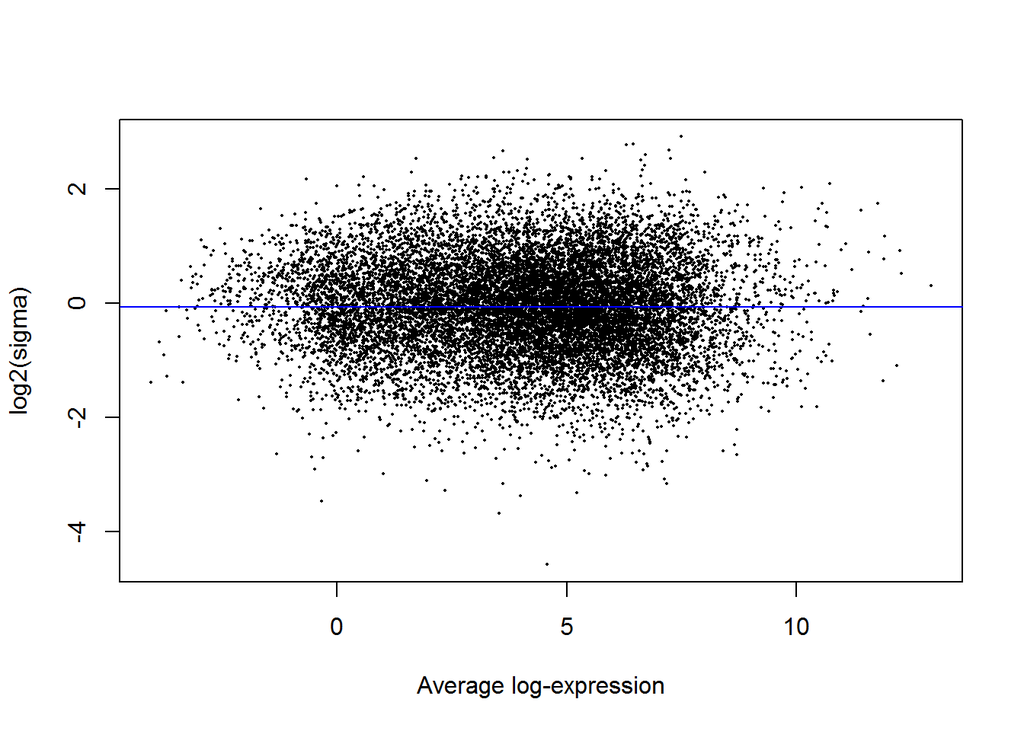

```r
## Fitting linear models for comparisons of interest
#vfit <- limma::lmFit(v, design);
uArrayLinearModelFit <- LinearModelFitToDesign(v, design);
#uArrayLinearModelContrast <- limma::contrasts.fit(uArrayLinearModelFit, contrasts = contr.matrix);
uArrayLinearModelContrast <- LinearModelFitToContrast(uArrayLinearModelFit, contrastMatrix = contr.matrix);
uArrayLinearModelebayes <- LinearModelFitToEmpBayes(uArrayLinearModelContrast);
PlotMicroArrayLinearModelSigmaVsAverageLogExpression(uArrayLinearModelebayes);
```

## Examining the number of *DE* genes

For a quick look at differential expression levels, the number of significantly up- and down-regulated genes can be summarised in a table. Significance is defined using an adjusted p-value cutoff that is set at 5% by default. For the comparison between expression levels in basal and LP, 4,127 genes are found to be down-regulated in basal relative to LP and 4,298 genes are up-regulated in basal relative to LP – a total of 8,425 DE genes. A total of 8,510 DE genes are found between basal and ML (4,338 down- and 4,172 up-regulated genes), and a total of 5,340 DE genes are found between LP and ML (2,895 down- and 2,445 up-regulated). The larger numbers of DE genes observed for comparisons involving the basal population are consistent with our observations from the MDS plots.

Some studies require more than an adjusted p-value cutoff. For a stricter definition on significance, one may require log-fold-changes (log-FCs) to be above a minimum value. The treat method17 can be used to calculate p-values from empirical Bayes moderated t-statistics with a minimum log-FC requirement. The number of differentially expressed genes are reduced to a total of 3,135 DE genes for basal versus LP, 3,270 DE genes for basal versus ML, and 385 DE genes for LP versus ML when testing requires genes to have a log-FC that is significantly greater than 1 (equivalent to a 2-fold difference between cell types on the original scale).

Genes that are DE in multiple comparisons can be extracted using the results from decideTests, where 0s represent genes that are not DE, 1s represent genes that are up-regulated, and -1s represent genes that are down-regulated. A total of 2,409 genes are DE in both basal versus LP and basal versus ML (Figure 5), twenty of which are listed below. The write.fit function can be used to extract and write results for all three comparisons to a single output file.

```r
## Examining the number of DE genes
#summary(limma::decideTests(uArrayLinearModelebayes));
DifferentialExpressionSum(uArrayLinearModelebayes);
```

```
##    BasalvsLP BasalvsML LPvsML
## -1      4127      4338   2895
## 0       5740      5655   8825
## 1       4298      4172   2445
```

```r
#tfit <- limma::treat(uArrayLinearModelContrast, lfc = 1);
tfit <- LinearModelTreatment(uArrayLinearModelContrast);
#dt <- limma::decideTests(tfit);
dt <- ClassifyTtestGenesAcross(tfit);
summary(dt);
```

```
##    BasalvsLP BasalvsML LPvsML
## -1      1417      1512    203
## 0      11030     10895  13780
## 1       1718      1758    182
```

```r
de.common <- which(dt[, columnBasalvsLP] != 0 & dt[, columnBasalvsML] != 0);
length(de.common);
```

```
## [1] 2409
```

```r
head(tfit$genes$SYMBOL[de.common], n = 20);
```

```
##  [1] "Xkr4"          "Rgs20"         "Cpa6"          "Sulf1"
##  [5] "Eya1"          "Msc"           "Sbspon"        "Pi15"
##  [9] "Crispld1"      "Kcnq5"         "Ptpn18"        "Arhgef4"
## [13] "2010300C02Rik" "Aff3"          "Npas2"         "Tbc1d8"
## [17] "Creg2"         "Il1r1"         "Il18r1"        "Il18rap"
```

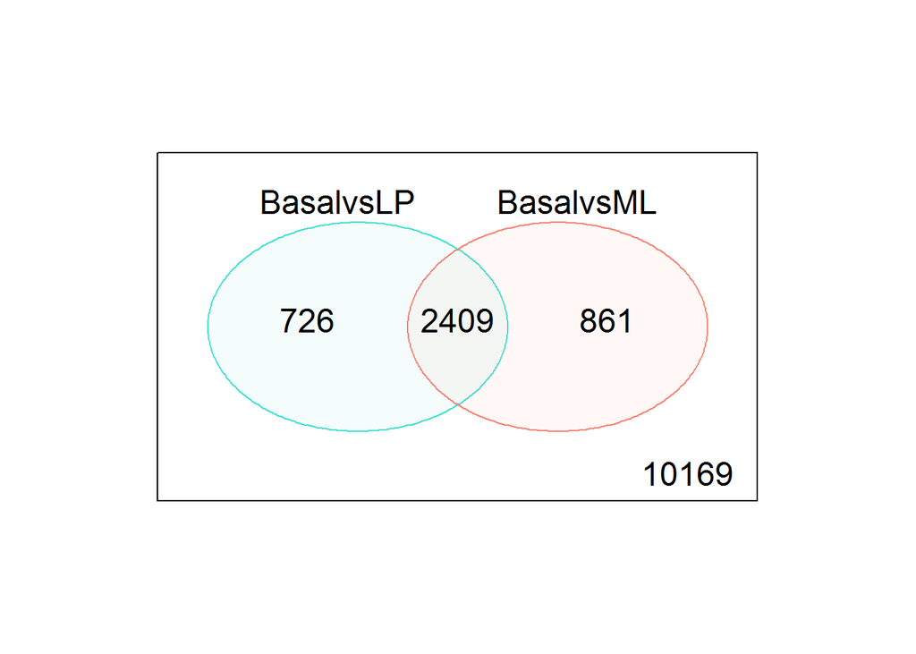

```r
#limma::vennDiagram(dt[,1:2], circle.col = c("turquoise", "salmon"));
TwoGroupVennDiagram(dt[, columnBasalvsLP:columnBasalvsML]);
```

```r
#limma::write.fit(tfit, dt, file = "Doc/results.txt");
MArrayLMToFile(tfit, aTestResults = dt, filePath = "Doc/results.txt");
```

**Figure 5.** Venn diagram showing the number of genes DE in the comparison between basal versus LP only (left), basal versus ML only (right), and the number of genes that are DE in both comparisons (center). The number of genes that are not DE in either comparison are marked in the bottom-right.

## Examining individual *DE* genes from top to bottom

```r
## Examining individual DE genes from top to bottom
#basal.vs.lp <- limma::topTreat(tfit, coef = 1, n = Inf);
basal.vs.lp <- LinearModelFitToTopGenes(tfit, coefficient = columnBasalvsLP);
head(basal.vs.lp);
```

```
##        ENTREZID SYMBOL TXCHROM     logFC  AveExpr         t
## 12759     12759    Clu   chr14 -5.442877 8.857907 -33.44429
## 53624     53624  Cldn7   chr11 -5.514605 6.296762 -32.94533
## 242505   242505  Rasef    chr4 -5.921741 5.119585 -31.77625
## 67451     67451   Pkp2   chr16 -5.724823 4.420495 -30.65370
## 228543   228543   Rhov    chr2 -6.253427 5.486640 -29.46244
## 70350     70350  Basp1   chr15 -6.073297 5.248349 -28.64890
##                   P.Value      adj.P.Val
## 12759  0.0000000003990899 0.000002703871
## 53624  0.0000000004503694 0.000002703871
## 242505 0.0000000006063249 0.000002703871
## 67451  0.0000000008010456 0.000002703871
## 228543 0.0000000011127291 0.000002703871
## 70350  0.0000000013805446 0.000002703871
```

```r
#basal.vs.ml <- limma::topTreat(tfit, coef = 2, n = Inf);
basal.vs.ml <- LinearModelFitToTopGenes(tfit, coefficient = columnBasalvsML);
head(basal.vs.ml);
```

```
##        ENTREZID  SYMBOL TXCHROM     logFC  AveExpr         t
## 242505   242505   Rasef    chr4 -6.510470 5.119585 -35.49093
## 53624     53624   Cldn7   chr11 -5.469160 6.296762 -32.52520
## 12521     12521    Cd82    chr2 -4.667737 7.070963 -31.82187
## 71740     71740 Nectin4    chr1 -5.556046 5.166292 -31.29987
## 20661     20661   Sort1    chr3 -4.908119 6.705784 -31.23083
## 15375     15375   Foxa1   chr12 -5.753884 5.625064 -28.34612
##                   P.Value      adj.P.Val
## 242505 0.0000000002573575 0.000001915485
## 53624  0.0000000004978446 0.000001915485
## 12521  0.0000000005796191 0.000001915485
## 71740  0.0000000006760578 0.000001915485
## 20661  0.0000000006761331 0.000001915485
## 15375  0.0000000014872804 0.000002281914
```

## Useful graphical representations of *DE* results *BasalvsLP*

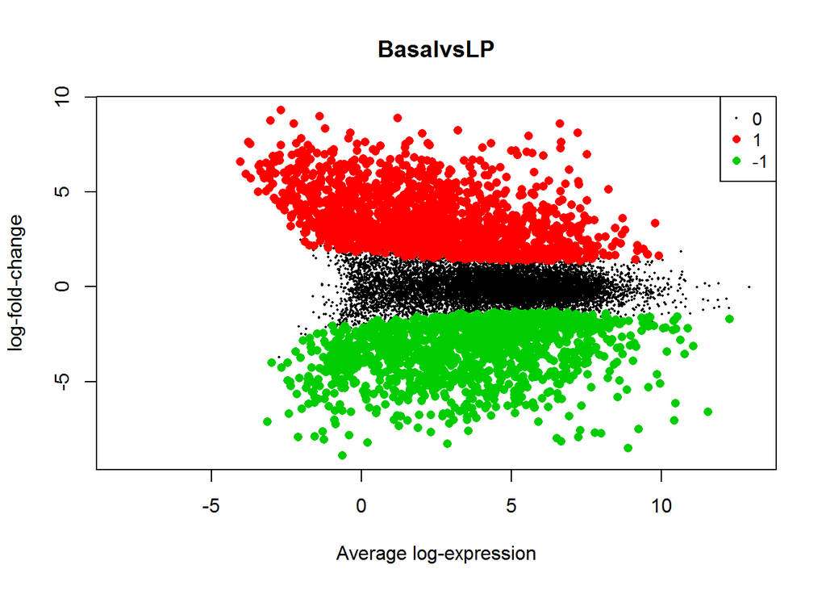

```r
PlotMeanDifferenceExpression(tfit, aColumn = columnBasalvsLP, aTestResults = dt);
```

```r
#***
Glimma::glMDPlot(tfit, coef = columnBasalvsLP, status = dt, main = colnames(tfit)[columnBasalvsLP],
        id.column = "ENTREZID", counts = x$counts, groups = group, launch = FALSE);
```

[output not shown]

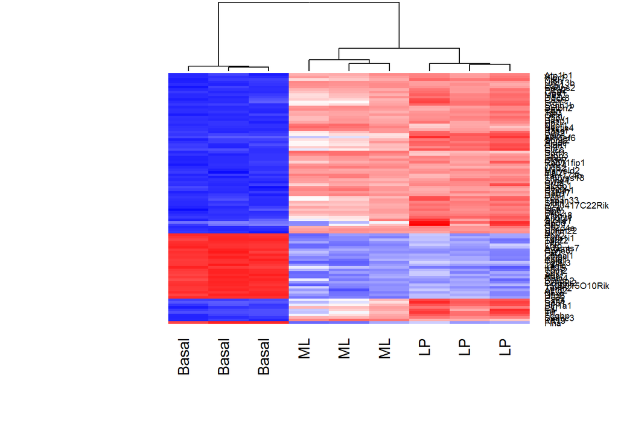

```r
#knitr::opts_chunk$set(error = TRUE);
library(gplots);
basal.vs.lp.topgenes <- basal.vs.lp$ENTREZID[1:100];
i <- which(v$genes$ENTREZID %in% basal.vs.lp.topgenes);
mycol <- gplots::colorpanel(1000, "blue", "white", "red");
gplots::heatmap.2(v$E[i, ], scale = "row",
          labRow = v$genes$SYMBOL[i], labCol = group,
          col = mycol, trace = "none", density.info = "none",
          margin = c(8, 6), lhei = c(2, 10), dendrogram = "column");
```

# Gene set testing with camera

```r
#load(url("http://bioinf.wehi.edu.au/software/MSigDB/mouse_c2_v5p1.rdata")) ;
load("Data/mouse_c2_v5p1.Rdata");
#idx <- limma::ids2indices(Mm.c2, identifiers = rownames(v)) ;
idx <- GeneIdsToGeneSets(Mm.c2, ids = rownames(v));
# <- limma::camera(v, index = idx, design, contrast = contr.matrix[, columnBasalvsLP]) ;
cam.BasalvsLP <- TestAccountingIntergeneCorrelation(anElist = v, indexList = idx, designMatrix = design,
                                                    contrastMatrix = contr.matrix[, columnBasalvsLP]);
head(cam.BasalvsLP,5);
```

```
##                                             NGenes Direction
## LIM_MAMMARY_STEM_CELL_UP                       739        Up
## LIM_MAMMARY_STEM_CELL_DN                       630      Down
## ROSTY_CERVICAL_CANCER_PROLIFERATION_CLUSTER    163        Up
## SOTIRIOU_BREAST_CANCER_GRADE_1_VS_3_UP         183        Up
## LIM_MAMMARY_LUMINAL_PROGENITOR_UP               87      Down
##                                                                 PValue
## LIM_MAMMARY_STEM_CELL_UP                    0.000000000000000001134757
## LIM_MAMMARY_STEM_CELL_DN                    0.000000000000001569957027
## ROSTY_CERVICAL_CANCER_PROLIFERATION_CLUSTER 0.000000000000143798724197
## SOTIRIOU_BREAST_CANCER_GRADE_1_VS_3_UP      0.000000000000218186155927
## LIM_MAMMARY_LUMINAL_PROGENITOR_UP           0.000000000000673461346591
##                                                                FDR
## LIM_MAMMARY_STEM_CELL_UP                    0.00000000000000536059
## LIM_MAMMARY_STEM_CELL_DN                    0.00000000000370823850
## ROSTY_CERVICAL_CANCER_PROLIFERATION_CLUSTER 0.00000000022643505770
## SOTIRIOU_BREAST_CANCER_GRADE_1_VS_3_UP      0.00000000025767785015
## LIM_MAMMARY_LUMINAL_PROGENITOR_UP           0.00000000063628628026
```

```r
# <- limma::camera(v, index = idx, design, contrast = contr.matrix[, columnBasalvsML]) ;
cam.BasalvsML <- TestAccountingIntergeneCorrelation(anElist = v, indexList = idx, designMatrix = design,
                                                    contrastMatrix = contr.matrix[, columnBasalvsML]);
head(cam.BasalvsML,5);
```

```
##                                             NGenes Direction
## LIM_MAMMARY_STEM_CELL_UP                       739        Up
## LIM_MAMMARY_STEM_CELL_DN                       630      Down
## LIM_MAMMARY_LUMINAL_MATURE_DN                  166        Up
## LIM_MAMMARY_LUMINAL_MATURE_UP                  180      Down
## ROSTY_CERVICAL_CANCER_PROLIFERATION_CLUSTER    163        Up
##                                                                      PValue
## LIM_MAMMARY_STEM_CELL_UP                    0.00000000000000000000005090937
## LIM_MAMMARY_STEM_CELL_DN                    0.00000000000000000051324461799
## LIM_MAMMARY_LUMINAL_MATURE_DN               0.00000000000000088751742485181
## LIM_MAMMARY_LUMINAL_MATURE_UP               0.00000000000062873014764214789
## ROSTY_CERVICAL_CANCER_PROLIFERATION_CLUSTER 0.00000000000168432284970170149
##                                                                     FDR
## LIM_MAMMARY_STEM_CELL_UP                    0.0000000000000000002404959
## LIM_MAMMARY_STEM_CELL_DN                    0.0000000000000012122837877
## LIM_MAMMARY_LUMINAL_MATURE_DN               0.0000000000013975441050000
## LIM_MAMMARY_LUMINAL_MATURE_UP               0.0000000007425303043653766
## ROSTY_CERVICAL_CANCER_PROLIFERATION_CLUSTER 0.0000000015913482283981675
```

```r
# <- limma::camera(v, index = idx, design, contrast = contr.matrix[, columnLPvsML]) ;
cam.LPvsML    <- TestAccountingIntergeneCorrelation(anElist = v, indexList = idx, designMatrix = design,
                                                    contrastMatrix = contr.matrix[, columnLPvsML]);
head(cam.LPvsML,5);
```

```
##                                         NGenes Direction
## LIM_MAMMARY_LUMINAL_MATURE_UP              180      Down
## LIM_MAMMARY_LUMINAL_MATURE_DN              166        Up
## LIM_MAMMARY_LUMINAL_PROGENITOR_UP           87        Up
## REACTOME_RESPIRATORY_ELECTRON_TRANSPORT     91      Down
## NABA_CORE_MATRISOME                        222        Up
##                                                         PValue
## LIM_MAMMARY_LUMINAL_MATURE_UP           0.00000000000008497295
## LIM_MAMMARY_LUMINAL_MATURE_DN           0.00000000000014398901
## LIM_MAMMARY_LUMINAL_PROGENITOR_UP       0.00000000003840914668
## REACTOME_RESPIRATORY_ELECTRON_TRANSPORT 0.00000002655349090998
## NABA_CORE_MATRISOME                     0.00000004430360969558
##                                                       FDR
## LIM_MAMMARY_LUMINAL_MATURE_UP           0.000000000340102
## LIM_MAMMARY_LUMINAL_MATURE_DN           0.000000000340102
## LIM_MAMMARY_LUMINAL_PROGENITOR_UP       0.000000060481603
## REACTOME_RESPIRATORY_ELECTRON_TRANSPORT 0.000031359672765
## NABA_CORE_MATRISOME                     0.000041858050440
```

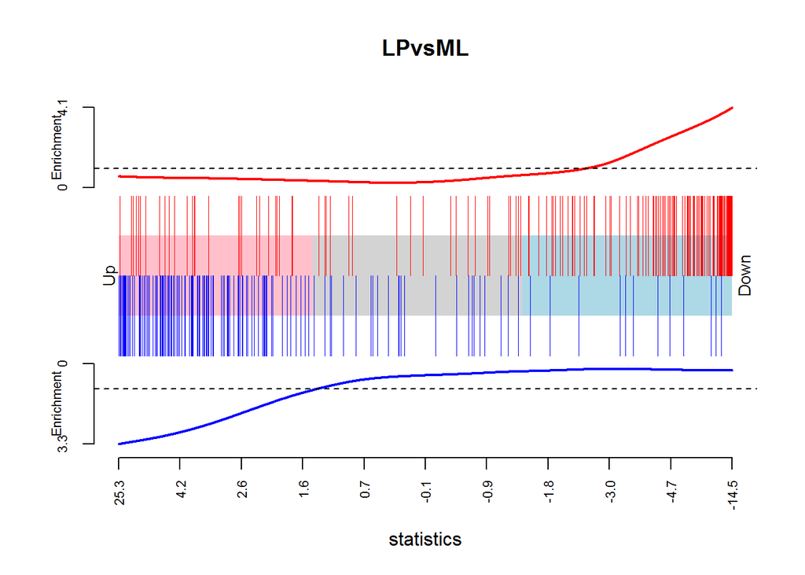

```r
# limma::barcodeplot(uArrayLinearModelebayes$t[, columnLPvsML], index = idx$LIM_MAMMARY_LUMINAL_MATURE_UP,
#             index2 = idx$LIM_MAMMARY_LUMINAL_MATURE_DN, main = "LPvsML");
PlotBarcodeEnrichment(statsVector = uArrayLinearModelebayes$t[, columnLPvsML],
                      indexVector = idx$LIM_MAMMARY_LUMINAL_MATURE_UP,
                      indexNegVector = idx$LIM_MAMMARY_LUMINAL_MATURE_DN, mainTile = "LPvsML");
```